# First document in HTML

Author

Luca Franceschinelli

## 1 Overview of Sara_dataset

| gender | major | cond | phobia | prevmath | mathquiz | statquiz | hr_base | hr_pre | hr_post | anx_base | anx_pre | anx_post |
| --- | --- | --- | --- | --- | --- | --- | --- | --- | --- | --- | --- | --- |
| 1 | 1 | 1 | 1 | 3 | 43 | 6 | 71 | 68 | 65 | 17 | 22 | 20 |
| 1 | 1 | 1 | 1 | 4 | 49 | 9 | 73 | 75 | 68 | 17 | 19 | 16 |
| 1 | 1 | 1 | 4 | 1 | 26 | 8 | 69 | 76 | 72 | 19 | 14 | 15 |
| 1 | 1 | 1 | 4 | 0 | 29 | 7 | 72 | 73 | 78 | 19 | 13 | 16 |
| 1 | 1 | 1 | 10 | 1 | 31 | 6 | 71 | 83 | 74 | 26 | 30 | 25 |
| 1 | 1 | 2 | 4 | 1 | 20 | 7 | 70 | 71 | 76 | 12 | 15 | 19 |
| 1 | 1 | 2 | 4 | 2 | 13 | 3 | 71 | 70 | 66 | 12 | 16 | 17 |
| 1 | 1 | 2 | 4 | 1 | 23 | 7 | 77 | 87 | 84 | 17 | 19 | 22 |
| 1 | 1 | 2 | 4 | 1 | 38 | 8 | 73 | 72 | 67 | 20 | 14 | 17 |
| 1 | 1 | 2 | 5 | 0 | NA | 7 | 78 | 76 | 74 | 20 | 24 | 19 |

[output cut: 90 more lines]

This is Sara_dataset, it’s a dataset that contains data of 100 subject on 13 variables.

- In the dataset there are 57 female subjects and 43 male subjects with five different type of undergraduate degree obtained (`major`).
- Subjects were divided in four experimental condition from easy to impossible (`cond`).
- Everyone describe their fear of mathematics on a scale from 0 to 10 (phobia) and the number of mathematics courses previously attended (`prevmath`).
- Tests consist in mathematics pre-test (mathquiz) and statistics test (statquiz) while subjects self-measured heart rate (normal, pre, post conditions `hr_base, hr_pre, hr_post`) and then took an anxiety test (normal, pre, post conditions `anx_base, anx_pre, anx_post`).

## 2 Analysis

### 2.1 Let’s do some descriptive statistics:

#### 2.1.1 Summary A:

```
     phobia         prevmath       mathquiz        statquiz
 Min.   : 0.00   Min.   :0.00   Min.   : 9.00   Min.   : 1.00
 1st Qu.: 1.00   1st Qu.:1.00   1st Qu.:22.00   1st Qu.: 6.00
 Median : 3.00   Median :1.00   Median :30.00   Median : 7.00
 Mean   : 3.31   Mean   :1.38   Mean   :29.07   Mean   : 6.86
 3rd Qu.: 4.00   3rd Qu.:2.00   3rd Qu.:35.00   3rd Qu.: 8.00
 Max.   :10.00   Max.   :6.00   Max.   :49.00   Max.   :10.00
                                NA's   :15
```

In *phobia* we can observe **simple relative frequency** from the graph (Figure 1).

We can also calculate mean and standard deviation to better comprehend this variable: mean = *Mean : 3.31* , sd = *2.44*.

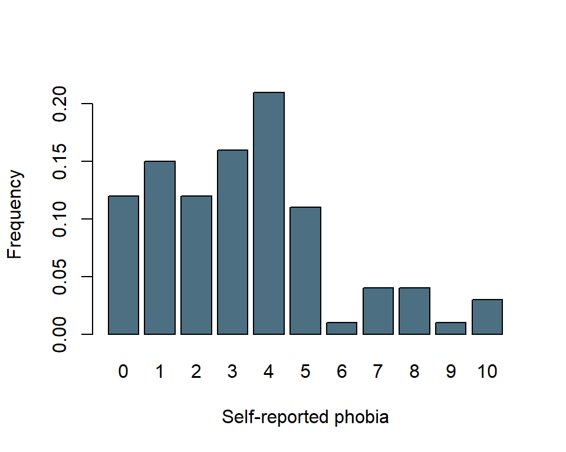

Figure 1: Simple relative frequency of mathematics fear

[figure not shown]

Figure 2: Fear of mathematics test

#### 2.1.2 Summary B:

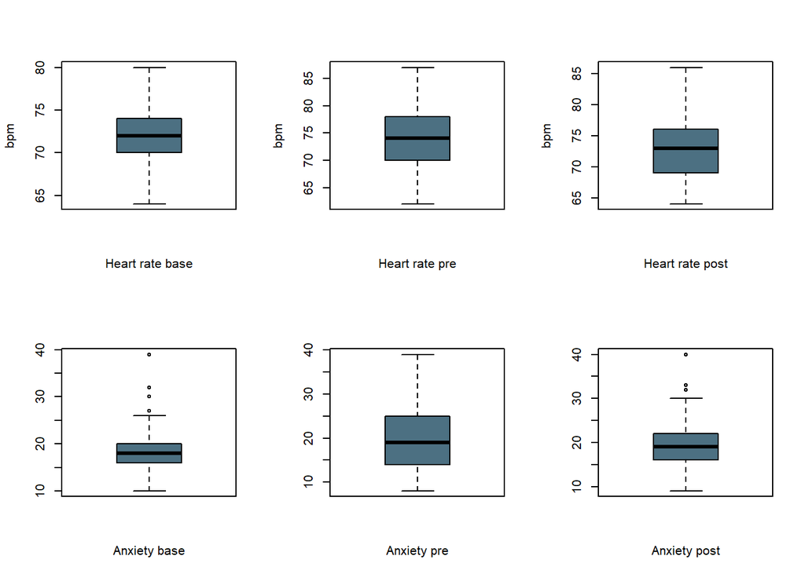

### 2.2 Analysis of two variables

First variable: phobia

```
     phobia
 Min.   : 0.00
 1st Qu.: 1.00
 Median : 3.00
 Mean   : 3.31
 3rd Qu.: 4.00
 Max.   :10.00
```

Standard deviation: 2.44

Second variable: mathquiz

```
    mathquiz
 Min.   : 9.00
 1st Qu.:22.00
 Median :30.00
 Mean   :29.07
 3rd Qu.:35.00
 Max.   :49.00
 NA's   :15
```

Standard deviation: 9.48

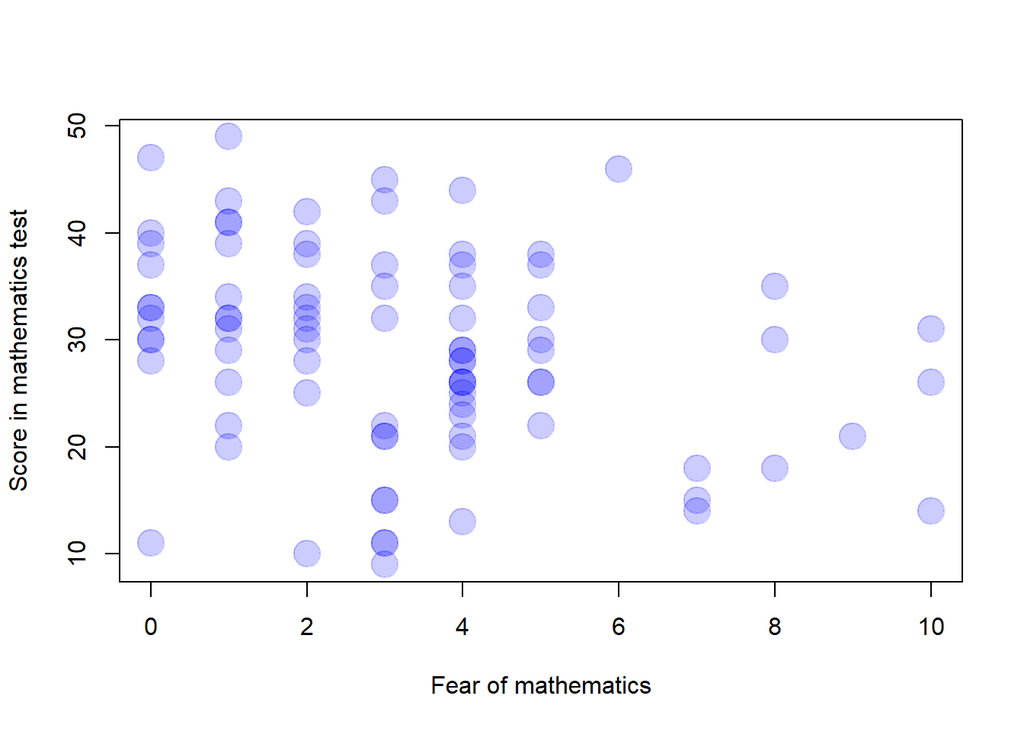

Figure 3: Scatterplot `phobia` x `mathquiz`

## 3 Conclusion

There’s an article about the fear in mathematics classroom (Whyte & Anthony, 2012), similar to Sara_dataset analyze above, it seems that more a person generally has less fear and higher score on mathematics test; as you can notice there are some missing values form mathquiz (exactly NA’s :15 NA’s). Fortunately, the majority of people remaining did have low *phobia* of mathematics test.

## References

Whyte, J., & Anthony, G. (2012). Maths anxiety: The fear factor in the mathematics classroom. *New Zealand Journal of Teachers’ Work*, *9*(1), 6–15.